# 双対平坦・双直交 Dually flat, dually orthogonal

ryamada

2017年3月5日

# 1 測地線 Geodesic

- 飛行機で遠くへ、たとえば大阪からロサンゼルスへ、行くとき、両都市の緯度は大体同じなので、その緯線に沿って飛ぶかと言えば、そんなことはなく、北東に向かって飛び始めて、だんだん真東へと向き、南東に向きを変えて到着する。Imagine a flight from Osaka to Los Angels, whose lattitudes are similar. The course is not along the lattitude line but it heads north-east first then heads to east and changes the direction to south-east.
- それが緯線に沿うよりも短距離だから。The flight course is the shortest path.
- 両都市を通る大円に近いコースを取っている。The flight path is along the great circle on which two cities are.
- この大円コースが球面での「まっすぐな線」である。This great circle course is “the straight line” on the sphere.
- したがって、地球表面に緯度・経度という座標の取り方(パラメタの取り方)をしたときには、「まっすぐな線」というのは、座標系に対しては曲線となることを意味している。From this, we can tell that straight lines are curved in the coordinate system of lattitude and longitude.
- このような曲がった空間でのまっすぐな線が測地線。The straight lines in the curved space are geodesics.

# 2 平坦 Flatness

- 空間には色々な座標の取り方があるが、ある座標系を取って、その座標をきれいな格子と考えて、地図を描き、その地図において、いわゆる直線で進むことにする。前の例では、緯線・経線を引いて、緯線に沿って進む、というような進み方である。We can assign various coordinate systems to a space. Assume you take paths that are linearly expressed in a coordinate system.
- この進み方が、「たまたま」測地線という意味でも「まっすぐな線」であるとき、この座標系の取り方は、「平坦」である、と言う。If the paths appearing straight in the coordinate system are geodesics, then the coordinate system is flat.

## 2.1 平坦とフィッシャー情報量と接続係数 Flatness, Fisher information and connection coefficient

- フィッシャー情報量は、局所の長さ・内積の測り方を決めている。Fisher information defines local elongation and inner product.
- フィッシャー情報量は座標系の取り方に応じて表現される。Fisher information’s expression depends on the coordinate systems.
- フィッシャー情報量は局所の長さを決めているので、曲線を引くときにその長さをどのくらいと見積もるかを決める。Fisher information tells local length, therefore it determins the length of curves/lines in the space because the length is integral of local lengths.
- したがって、フィッシャー情報量が(フィッシャー情報量を構成する関数の変化具合が)曲線に沿ってどう変化するかを検討することで、どのような座標系の取り方は、平坦なのかが解る。This means that the changes of Fisher information along a curve have information whether the curves are geodesics and also have information on flatness of coordinate system.
- 実際、平坦ならば、0になるべき要素を接続係数$F_{ki,j}^{(\alpha)}$と呼ぶが、それは以下で示されることからもその様子が見て取れる。Actually connection coeffcicient $F_{ki,j}^{(\alpha)}$ is defined so that $F_{ki,j}^{(\alpha)}$ should be zero when flat. The formula below implicates that connection coefficients are closely related to Fisher information.

$$g(ij) = \int \frac{\partial 2\sqrt{p}}{\partial \theta_i}\frac{\partial 2\sqrt{p}}{\partial \theta_j} dx\\
= \int \frac{\partial l^{(\alpha)}}{\partial \theta_i}\frac{\partial l^{(-\alpha)}}{\partial \theta_j} dx\\$$

$$F_{ki,j}^{(\alpha)} =\int \frac{\partial}{\partial \theta_k}\frac{\partial l^{(\alpha)}}{\partial \theta_i}\frac{\partial l^{(-\alpha)}}{\partial \theta_j} dx$$

- ただし、$l^{(\alpha)}$はフィッシャー情報量をうまく２つの関数の偏微分の積を使って表すために登場した関数。where $l^{(\alpha)}$ stands for function that expresses Fisher information as product of partial derivatives of them.

$$l^{(\alpha)} = \frac{2}{1-\alpha}p^{\frac{1-\alpha}{2}}; \alpha \ne 1\\
= \log{p}; \alpha = 1$$

# 3 二重平坦 Dually flat

## 3.1 正規分布の例 Example; Normal distribution

- 平均m、標準偏差sで表現すれば、Formula of normal distribution with mean $m$ and standard deviation $s$.
  $$p(x|m,s) = \frac{1}{\sqrt{2\pi}s}e^{-\frac{(x-m)^2}{2s^2}}$$
- これに$(m,s)$という二次元座標を与えた、と見ることができる。This formula can be read that 2d coordinates $(m,s)$ are given to the distribution.
- 今、異なる２つの座標系$(\theta_1,\theta_2)$,$(\eta_1,\eta_2)$を与える。We take two different coordinate systems $(\theta_1,\theta_2)$,$(\eta_1,\eta_2)$ as below.
- それぞれ、$\alpha = 1$,$\alpha=-1$に対応する２つの座標系として知られているものである。They are known as coordinate systems corresponding to $\alpha = 1$,$\alpha=-1$.

$$\theta_1 = \frac{m}{s^2}\\
\theta_2 = -\frac{1}{2s^2}\\
m = -\frac{\theta_1}{2\theta_2}\\
s^2 = -\frac{1}{2\theta_2}$$

$$\eta_1 = m\\
\eta_2 = m^2+s^2\\
m = \eta_1\\
s^2 = \eta_2- \eta_1^2$$

- $(\theta_1,\theta_2)$の格子を描く Let’s draw lattice of $(\theta_1,\theta_2)$
- 位置によって、格子が作る伸び縮みの具合は変化しているし、直交しているわけでもない The lattice is deformed and the features of elongation varies among locations and the angles are not perpendicular.
- 今、描図に用いている$(m,s)$が絶対的な座標系ではないので、伸び縮みの変化や角度が「本当のところ」はどうなっているのかは、図からは分からない。それはフィッシャー情報量を各所で調べることによってわかる The coordinate system $(m,s)$ is one of many coodinate systems and it is not the right one. Therefore this drawing does not tell “real” elongation features of $(\theta_1,\theta_2)$ system. If you want to know the “real” elongation, you have to check its Fisher information.

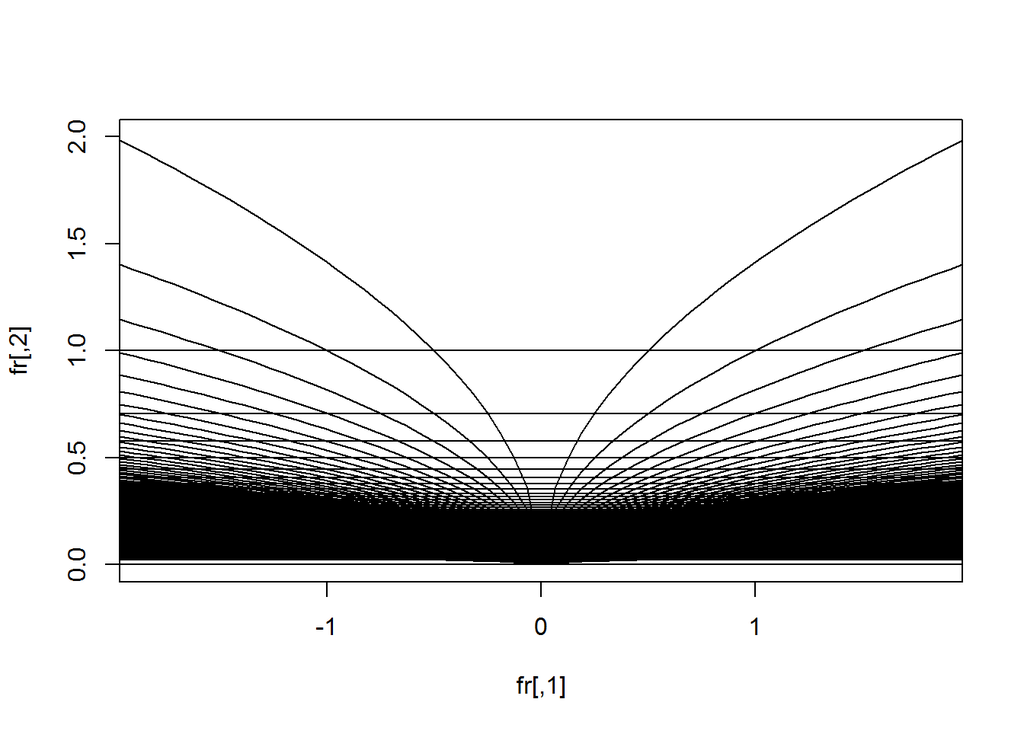

```r
# 正規分布、(m,s)座標に(theta1,theta2)格子
# (theta1,theta2) lattice on the map with (m,s) coordiante system
# s^2 = m/theta1
# s^2 = -1/(2theta2)
theta1 <- seq(from=1/2,to=1000,by=1/2)
theta2 <- -seq(from=1/2,to=1000,by=1/2)
fr <- matrix(c(-1,0,1,1),byrow=TRUE,2,2)
plot(fr,asp=1,col=0,ylim=c(0,2))

t <- seq(from=0,to=1,length=100) * 2*pi

for(i in 1:length(theta1)){
  points(t,sqrt(t/theta1[i]),type="l")
  points(-t,sqrt(t/theta1[i]),type="l")

}

for(i in 1:length(theta2)){
    abline(h=sqrt(-1/(2*theta2[i])))
}
abline(h=0)
```

- $(\eta_1,\eta_2)$の格子を描くLet’s draw lattice of $(\eta_1,\eta_2)$
- 位置によって、格子が作る伸び縮みの具合は変化しているし、直交しているわけでもない Elongation feaures depends on location. Not perpendicular.
- 今、描図に用いている$(m,s)$が絶対的な座標系ではないので、伸び縮みの変化や角度が「本当のところ」はどうなっているのかは、図からは分からない。それはフィッシャー情報量を各所で調べることによってわかる For the true elongation, check Fisher information.

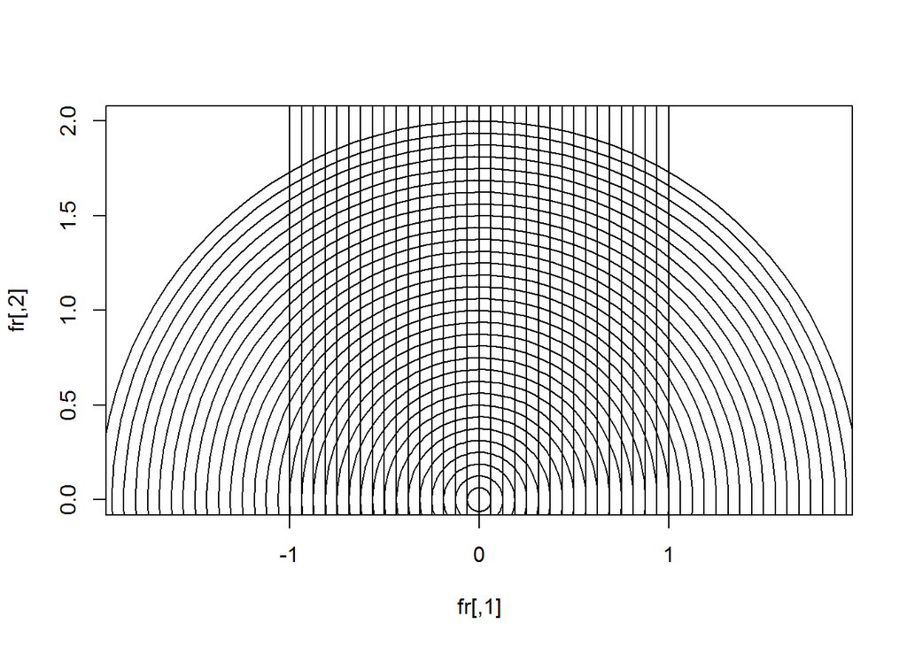

```r
# 正規分布、(m,s)座標に(eta1,eta2)格子
# (eta1,eta2) lattice on the map with (m,s) coordiante system

# m = eta1
# m^2+s^2=eta2
eta1 <- seq(from=-1,to=1,by=1/(2^4))
eta2 <- seq(from=0,to=2,by=1/(2^4))

fr <- matrix(c(-1,0,1,1),byrow=TRUE,2,2)
plot(fr,asp=1,col=0,ylim=c(0,2))

for(i in 1:length(eta1)){
    abline(v=eta1[i])
}
t <- seq(from=0,to=1,length=100) * 2*pi
for(i in 1:length(eta2)){
    points(eta2[i] * cos(t),eta2[i] * sin(t),type="l")
}
```

- $(\theta_1,\theta_2)$と$(\eta_1,\eta_2)$の2種類の格子を重ねてみる Draw two coordinate system lattice together.

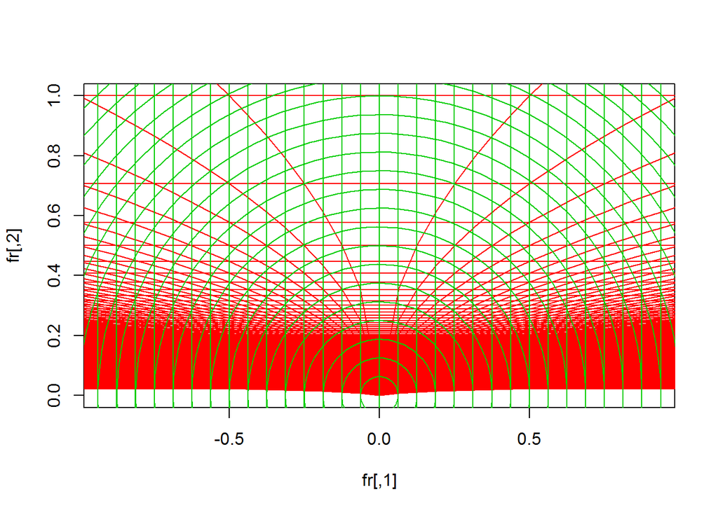

```r
fr <- matrix(c(-0.5,0,0.5,0.5),byrow=TRUE,2,2)
plot(fr,asp=1,col=0,ylim=c(0,1))
t <- seq(from=0,to=1,length=100) * 2*pi

for(i in 1:length(theta1)){
  points(t,sqrt(t/theta1[i]),type="l",col=2)
  points(-t,sqrt(t/theta1[i]),type="l",col=2)

}

for(i in 1:length(theta2)){
    abline(h=sqrt(-1/(2*theta2[i])),col=2)
}
for(i in 1:length(eta1)){
    abline(v=eta1[i],col=3)
}
t <- seq(from=0,to=1,length=100) * 2*pi
for(i in 1:length(eta2)){
    points(eta2[i] * cos(t),eta2[i] * sin(t),type="l",col=3)
}
```

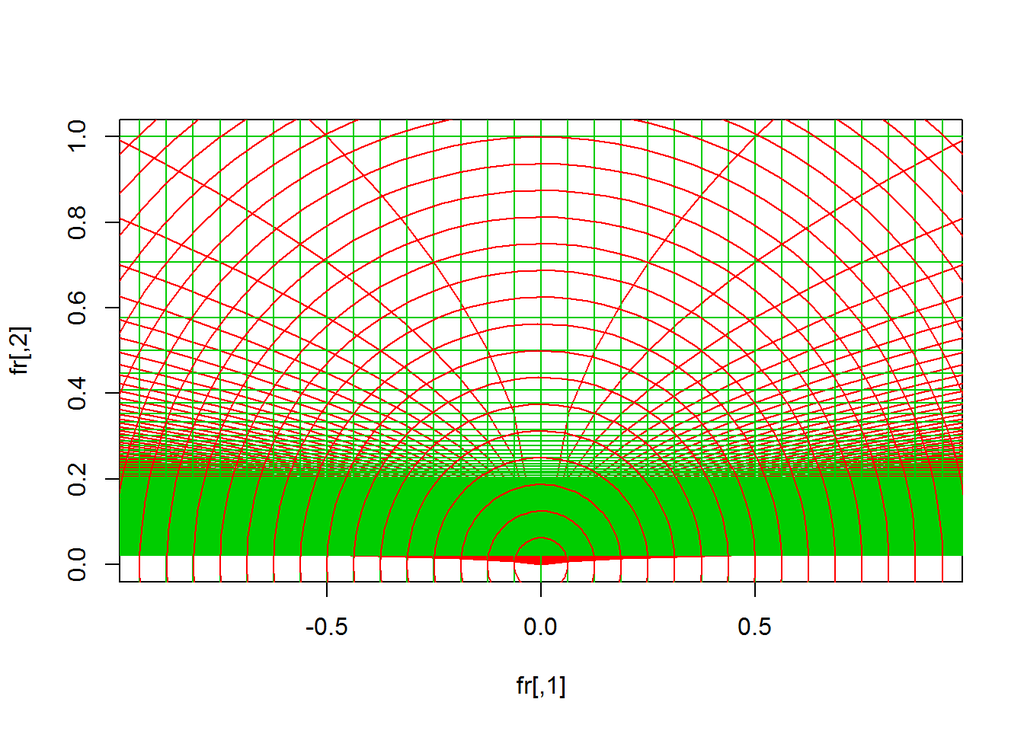

```r
fr <- matrix(c(-0.5,0,0.5,0.5),byrow=TRUE,2,2)
plot(fr,asp=1,col=0,ylim=c(0,1))
t <- seq(from=0,to=1,length=100) * 2*pi

for(i in 1:length(theta1)){
  points(t,sqrt(t/theta1[i]),type="l",col=2)
  points(-t,sqrt(t/theta1[i]),type="l",col=2)
    #segments(0,0,2,2/theta1[i],col=2)
    #segments(0,0,-2,2/theta1[i],col=2)
}

for(i in 1:length(theta2)){
    abline(h=sqrt(-1/(2*theta2[i])),col=3)
}
for(i in 1:length(eta1)){
    abline(v=eta1[i],col=3)
}
t <- seq(from=0,to=1,length=100) * 2*pi
for(i in 1:length(eta2)){
    points(eta2[i] * cos(t),eta2[i] * sin(t),type="l",col=2)
}
```

# 4 双対座標系 Dual coordinate system

- 正規分布は2次元多様体であるので、２次元座標を与えられる Coordinate systems of normal distribution is 2d.
- 二つの座標系$(\theta_1,\theta_2)$,$(\eta_1,\eta_2)$を示した Two systems $(\theta_1,\theta_2)$ and $(\eta_1,\eta_2)$ were introduced above.
- この座標系は、正規分布が持つ特別な座標系ペアである They are special for normal distribution.
- どちらも平坦 Both are flat.
- 相互に直交(双直交) Theya re mutually orthogonal (dually orthogonal).
- どちらも、平坦であるというのは、座標系を「信じて」まっすぐに進むとそれが測地線になること。このことは、それぞれの座標系が持つ性質であって、２つの座標系の関係を考える必要がない Both are flat, which means that straight paths in either coordinate system are geodesics. This feature is intrinsic for both system and no interaction between two systems.
- 相互に直交(双直交)であることを考えるには、それぞれの座標系の個々の要素に対応付けをする必要がある。$\theta_1$と$\eta_1$とは、ある理由で対応があり、その同じ理由で$\theta_2$と$\eta_2$とも対応がある、と言うような関係である。一般に、k次元の場合も$\theta_i$と$\eta_i$,$i=1,2,...,k$に対応がある The dual orthogonality is the feature between two systems. Therefore we need a piece of rule between the two systems. The elements of $\theta$ system, and the elements of $\eta$ system are in the one-to-one correspondence relation. $\theta_1$ is something specific for $\eta_1$ but not for $\eta_2$.
- このとき、$\theta_i$と$\eta_j$とに関する、偏微分ベクトル(局所の座標方向のベクトルであって、伸び縮みを表すベクトル)同士が、正規直行基底であるかのような性質を持ち、そのことを双直交と言う Now we have mutual relation among $\theta_i$ and $\eta_j$ depending on $i=j$ or $i \ne j$ and the set of partial derivative vectors of $\theta$ system and the set of partial derivative vectors of $\eta$ system are in the relation where the inner products of both system vectors orthonormal. And this relation is called dual orthonormal.
- 正規直行基底であるかのよう、とは、$i =j$のときには、内積が1であり、$i\ne j$のときには内積が0となることである It means that the inner product of the partial derivative vectors of $\theta_i$ and $\eta_i$ is 1 and the inner product of vectors of $\theta_i$ and $\eta_j$, where $i \ne j$, is 0.
- $\theta_i$と$\eta_j$とに関する、偏微分ベクトルと書いたが、
- $\theta_i$ のそれは$l^{(\alpha=1)}=\log{p}$から来る座標系なので、その偏微分ベクトルは$\frac{\partial \log{p}}{\partial \theta_i}$である
- 他方$\eta_i$のそれは$l^{(\alpha=-1)}=p$から来る座標系なので、その偏微分ベクトルは$\frac{\partial p}{\partial \eta_i}$。The partial derivative vectors are somewhat different between $\theta$ system and $\eta$ system. For $\theta$ system, differentiate $\log{p}$ and for $\eta$ system, differentiate $p$ itself.
- 別の言い方もできる。$\int \frac{\partial \log{p}}{\partial \theta_i} \frac{\partial p}{\partial \eta_i} dx$は$\int \frac{\partial \log{p}}{\partial \theta_i} \frac{\partial \log{p}}{\partial \eta_i} \times p dx$と変形できるから、$\log{p}$の$\theta_i$と$\eta_j$とのそれぞれの偏微分の期待値が1または0になる関係でもある Another explanation is also possible. $\int \frac{\partial \log{p}}{\partial \theta_i} \frac{\partial p}{\partial \eta_i} dx$ can be transformed to $\int \frac{\partial \log{p}}{\partial \theta_i} \frac{\partial \log{p}}{\partial \eta_i} \times p dx$. This means $\log{p}$ is partially differentiated with $\theta_i$ and $\eta_j$ and their “expected value” is 1 or 0.

## 4.1 正規分布の例 Example, normal distribution

- 具体例で確認する Confirm what the above descriptions mean with an example.
- ある正規分布$N(m,s^2)$を考え、それを、少し変化させる。変化させる方向は$\theta_1$,$\theta_2$,$\eta_1$,$\eta_2$とすれば、それぞれの微小変化によって正規分布が変わる、$x \in R$全体にわたって増えたり減ったりする Take an instance of normal distribution $N(m,s^2)$ and change its parameters a bit. The direction of change is in $\theta_1$,$\theta_2$,$\eta_1$ or $\eta_2$. With the change in any one of four directions, values of normal distributio for $x \in R$ changes everywhere.
- その変化の総和(xに関する積分)をパラメタの増分で割ったものが、$\frac{\partial \log{p}}{\partial \theta_i}$だったり、$\frac{\partial p}{\partial \eta_j}$となる The integral of the changes throughout $x$ should divieded by the change in parameter value, that is approxiamtion of derivative.
- それを確かめるために、$(m,s)$と$(\theta_1,\theta_2)$,$(\eta_1,\eta_2)$とを変換する関数や、$(\theta_1,\theta_2)$のときの$\log{N(m,s)}$の値や$(\eta_1,\eta_2)$のときの$N(m,s)$の値を算出する関数を作る First make some utility functions to perform this numeric experiments.
- 座標の相互変換の関数 Functions to convert coordinates among three systems.

```r
my.ms2theta <- function(m,s){
    theta1 <- m/(s^2)
    theta2 <- -1/(2*s^2)
    return(c(theta1,theta2))
}

my.ms2eta <- function(m,s){
    eta1 <- m
    eta2 <- s^2+m^2
    return(c(eta1,eta2))
}

my.theta2ms <- function(theta1,theta2){
    m <- -theta1/(2*theta2)
    s <- sqrt(-1/(2*theta2))
    return(c(m,s))
}

my.eta2ms <- function(eta1,eta2){
    m <- eta1
    s <- sqrt(eta2-eta1^2)
    return(c(m,s))
}

my.theta2eta <- function(theta1,theta2){
    ms <- my.theta2ms(theta1,theta2)
    my.ms2eta(ms[1],ms[2])
}
my.eta2theta <- function(eta1,eta2){
    ms <- my.eta2ms(eta1,eta2)
    my.ms2theta(ms[1],ms[2])
}
```

- それぞれの座標系で、$\log{p}$,$p$を返す関数を作る Functions to return $\log{p}$ or $p$ for each coordinate systems.

```r
# theta系はlog(p)
my.dnorm.theta <- function(x,theta1,theta2,log=TRUE){
    ms <- my.theta2ms(theta1,theta2)
    dnorm(x,ms[1],ms[2],log=log)
}
# eta系はp
my.dnorm.eta <- function(x,eta1,eta2,log=FALSE){
    ms <- my.eta2ms(eta1,eta2)
    dnorm(x,ms[1],ms[2],log=log)
}
```

- ある特定の正規分布$m0 = 2, s0 = 1$について偏微分ベクトルを求め、双直交性を確認する Take an example normal distribution with $m0 = 2, s0 = 1$ and calculate numeric approximates of partial derivatives for 4 directional chnges.

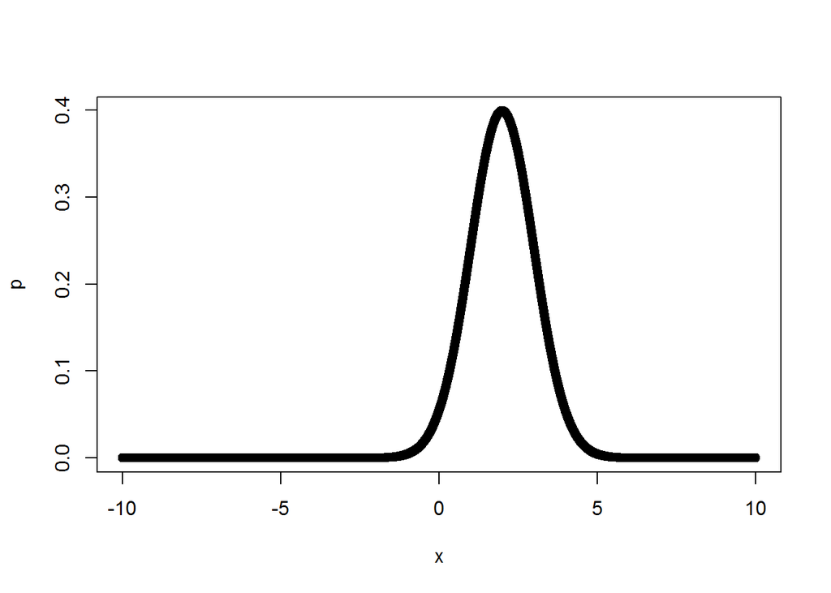

```r
m0 <- 2
s0 <- 1
dx <- 1/1000
x <- seq(from=-10,to=10,by=dx)
p <- dnorm(x,m0,s0)
plot(x,p)
```

- 対応する$\theta,\eta$を求める $\theta,\eta$?

```r
thetas <- my.ms2theta(m0,s0)
etas <- my.ms2eta(m0,s0)
```

- $\theta_1$の偏微分を求める。その増減の様子を描く Partial derivative in the direction of $\theta_1$.

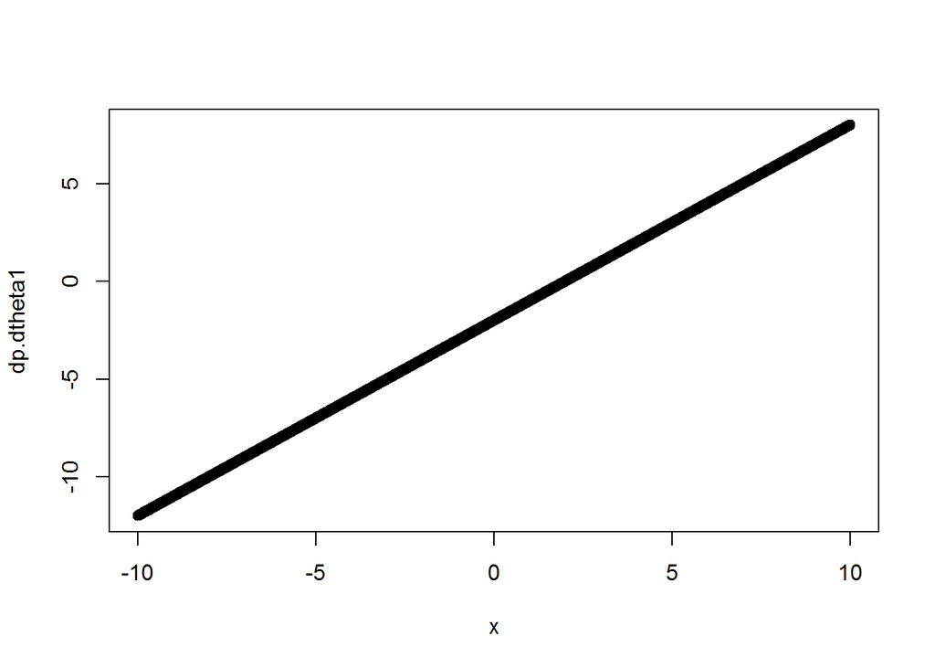

```r
d.theta1 <- 0.0001
dp.dtheta1 <- (my.dnorm.theta(x,thetas[1]+d.theta1,thetas[2]) - my.dnorm.theta(x,thetas[1],thetas[2]))/d.theta1

plot(x,dp.dtheta1)
```

- $\theta_2,\eta_1,\eta_2$についても同様に求める Same for $\theta_2,\eta_1,\eta_2$.

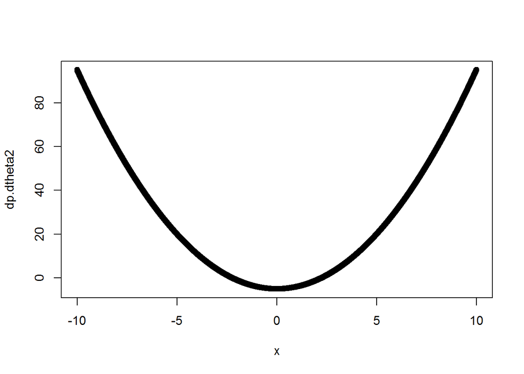

```r
d.theta2 <- 0.0001

d.eta1 <- 0.0001
d.eta2 <- 0.0001


dp.dtheta2 <- (my.dnorm.theta(x,thetas[1],thetas[2]+d.theta2) - my.dnorm.theta(x,thetas[1],thetas[2]))/d.theta2
plot(x,dp.dtheta2)
```

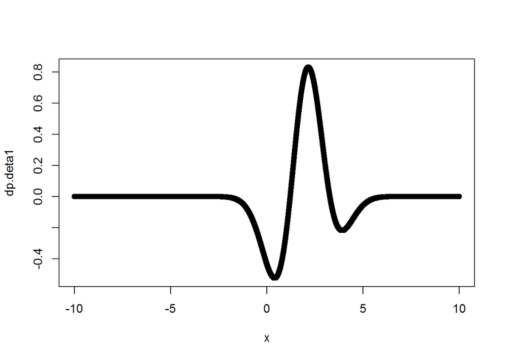

```r
dp.deta1 <- (my.dnorm.eta(x,etas[1]+d.eta1,etas[2]) - my.dnorm.eta(x,etas[1],etas[2]))/d.eta1
plot(x,dp.deta1)
```

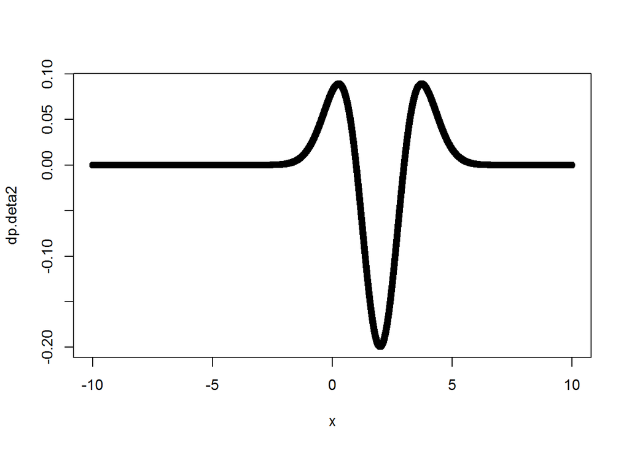

```r
dp.deta2 <- (my.dnorm.eta(x,etas[1],etas[2]+d.eta2) - my.dnorm.eta(x,etas[1],etas[2]))/d.eta2
plot(x,dp.deta2)
```

- 双直交性の確認 Dual orthogonality is confirmed as;

```r
sum(dp.dtheta1 * dp.deta1) * diff(x)[1]
```

```
## [1] 1
```

```r
sum(dp.dtheta1 * dp.deta2) * diff(x)[1]
```

```
## [1] -1.513625e-13
```

```r
sum(dp.dtheta2 * dp.deta1) * diff(x)[1]
```

```
## [1] 1.013927e-11
```

```r
sum(dp.dtheta2 * dp.deta2) * diff(x)[1]
```

```
## [1] 1
```